# Problem Set 10

Lauren Sullivan, BIO_SC 8002_01

Due May 6, 2022

## Liver Toxicity

```r
###############
#
# 10 PROBLEM SET
#
# DUE:        May 6, 2020
#
# CREATED BY: Lauren Sullivan
# FILES:      "liver.toxicity.csv"
#             "dune.csv"
#             "dune.env.csv"
#
###############


########### setup
rm(list=ls())


library(tidyverse)
library(vegan)  #for standardization, distance matrices and nmds
library(stats)  # for PCA
library(ggbiplot) # for graphing PCA

########### data
liver <- read_csv("../data/liver.toxicity.csv")
dune <- read_csv("../data/dune.csv")
dune.env <- read_csv("../data/dune.env.csv")
```

### Background

For the first part of this homework, we will be using a dataset examining the gene expression that occurs under liver toxicity when rats are placed on four different doses of acetaminophen (50, 150, 1500, and 2000 mg/kg). There are 64 rats in this study, with 16 in each dosage treatment. The datafile is “liver.toxicity.csv”. We will look at how the **Y** of gene expression data is influenced by the dosage treatment. This data comes from a larger R package [looking at gene expression and PCA](https://mixomicsteam.github.io/Bookdown/pca.html#biological-question). You can find it within `library(mixOmics)`, which is now stored in `library("BiocManager")` - [download it here](https://www.bioconductor.org/packages/release/bioc/html/mixOmics.html).

**Q1** Let’s start by looking at the data. You will notice that this dataset is extremely wide. So, let’s look at the first 20 rows and the first 10 columns of the data. Describe what the data look like (what is in each row, column and cell).

```r
liver[1:20, 1:6]
```

```
## # A tibble: 20 × 6
##    Animal.Number Treatment.Group Dose.Group A_43_P14555 A_43_P22290 A_43_P20792
##            <dbl> <chr>                <dbl>       <dbl>       <dbl>       <dbl>
##  1           202 50 MG/KG6 HR            50     0.0517     -0.0812      0.00617
##  2           203 50 MG/KG6 HR            50     0.0155      0.175       0.0484
##  3           204 50 MG/KG18 HR           50    -0.0151     -0.0479     -0.0231
##  4           206 50 MG/KG18 HR           50    -0.0265      0.0241     -0.00558
##  5           208 50 MG/KG24 HR           50     0.0500      0.0221     -0.0254
##  6           209 50 MG/KG24 HR           50     0.0440     -0.0693     -0.0266
##  7           210 50 MG/KG48 HR           50     0.00836     0.0516     -0.00357
##  8           211 50 MG/KG48 HR           50    -0.0415     -0.0306     -0.0679
##  9           212 50 MG/KG48 HR           50    -0.0439     -0.0106      0.00856
## 10           213 50 MG/KG6 HR            50    -0.00975     0.0780      0.0239
## 11           214 50 MG/KG6 HR            50     0.129       0.0241     -0.0196
## 12           216 50 MG/KG18 HR           50     0.185      -0.0188      0.0134
## 13           217 50 MG/KG18 HR           50     0.180       0.221       0.0340
## 14           220 50 MG/KG24 HR           50     0.0513      0.0743      0.0204
## 15           221 50 MG/KG24 HR           50     0.0904      0.235       0.111
## 16           223 50 MG/KG48 HR           50    -0.0242     -0.0268      0.00495
## 17           302 150MG/KG6 HR           150    -0.00667    -0.00602    -0.0278
## 18           303 150MG/KG6 HR           150     0.0530      0.0115     -0.00709
## 19           306 150MG/KG18 HR          150    -0.119      -0.0842     -0.0710
## 20           307 150MG/KG24 HR          150    -0.107      -0.0231     -0.0101
```

```r
## looks like each rat has its own row, and its own treatment/dose
#   of acetomenaphen. And each column after that are genes, with
#   their expression of that particular gene (not sure the units)
#   in each cell.
```

### PCA

**Q2** Run a PCA on the data using `prcomp()`, and summarize the data using `summary()`. Describe what this tells you. What does the standard deviation row tell you? How much variance does the 1st, 2nd, and 6th principal component, or axis, describe?

```r
liver.pca <- prcomp(liver[, -c(1:3)], center = TRUE, scale = TRUE)
summary(liver.pca)
```

```
## Importance of components:
##                            PC1     PC2      PC3      PC4      PC5      PC6
## Standard deviation     29.5767 21.5198 15.75284 12.94521 11.91457 11.06001
## Proportion of Variance  0.2807  0.1486  0.07964  0.05378  0.04556  0.03926
## Cumulative Proportion   0.2807  0.4294  0.50900  0.56278  0.60833  0.64759
##                             PC7     PC8     PC9    PC10    PC11    PC12   PC13
## Standard deviation     10.42905 8.81737 8.61300 7.51370 7.33788 6.71042 6.4615
## Proportion of Variance  0.03491 0.02495 0.02381 0.01812 0.01728 0.01445 0.0134
## Cumulative Proportion   0.68250 0.70745 0.73125 0.74937 0.76665 0.78110 0.7945
##                           PC14    PC15    PC16    PC17    PC18    PC19    PC20
## Standard deviation     5.77046 5.49484 5.32941 5.09056 4.94436 4.89087 4.73424
## Proportion of Variance 0.01069 0.00969 0.00912 0.00832 0.00785 0.00768 0.00719
## Cumulative Proportion  0.80519 0.81488 0.82399 0.83231 0.84015 0.84783 0.85502
##                           PC21    PC22   PC23    PC24    PC25    PC26    PC27
## Standard deviation     4.61732 4.54974 4.2869 4.23196 4.20055 4.06784 4.00914
## Proportion of Variance 0.00684 0.00664 0.0059 0.00575 0.00566 0.00531 0.00516
## Cumulative Proportion  0.86187 0.86851 0.8744 0.88015 0.88582 0.89113 0.89629
##                           PC28    PC29    PC30    PC31    PC32    PC33    PC34
## Standard deviation     3.99912 3.83156 3.70055 3.68072 3.60669 3.58842 3.56746
## Proportion of Variance 0.00513 0.00471 0.00439 0.00435 0.00417 0.00413 0.00408
## Cumulative Proportion  0.90142 0.90613 0.91052 0.91487 0.91905 0.92318 0.92726
##                           PC35    PC36    PC37    PC38    PC39    PC40    PC41
## Standard deviation     3.46103 3.42442 3.40608 3.31792 3.21253 3.19619 3.14483
## Proportion of Variance 0.00384 0.00376 0.00372 0.00353 0.00331 0.00328 0.00317
## Cumulative Proportion  0.93111 0.93487 0.93859 0.94213 0.94544 0.94872 0.95189
##                           PC42    PC43    PC44   PC45    PC46    PC47    PC48
## Standard deviation     3.04882 2.97013 2.95791 2.8980 2.87302 2.83888 2.79671
## Proportion of Variance 0.00298 0.00283 0.00281 0.0027 0.00265 0.00259 0.00251
## Cumulative Proportion  0.95488 0.95771 0.96051 0.9632 0.96586 0.96845 0.97096
##                           PC49    PC50    PC51    PC52    PC53   PC54    PC55
## Standard deviation     2.78269 2.70859 2.67189 2.63495 2.60485 2.5567 2.52330
## Proportion of Variance 0.00249 0.00235 0.00229 0.00223 0.00218 0.0021 0.00204
## Cumulative Proportion  0.97344 0.97579 0.97809 0.98031 0.98249 0.9846 0.98663
##                           PC56    PC57    PC58    PC59    PC60    PC61    PC62
## Standard deviation     2.46071 2.45534 2.38118 2.32025 2.24477 2.19590 2.13864
## Proportion of Variance 0.00194 0.00193 0.00182 0.00173 0.00162 0.00155 0.00147
## Cumulative Proportion  0.98858 0.99051 0.99233 0.99406 0.99567 0.99722 0.99869
##                           PC63      PC64
## Standard deviation     2.02014 1.313e-14
## Proportion of Variance 0.00131 0.000e+00
## Cumulative Proportion  1.00000 1.000e+00
```

```r
# The summary(liver.pca) describes how much variance each PC axis
#   explains. There should be as many PC axes as there are columns
#   of data, however in this case there are so many columns that it
#   seems likely that they only estimate 64 PC's because that's where
#   the variation explained reaches 1, and each additional PC axis
#   only infintesimally explains more variation and so they are not
#   included.

# THis summary details three things.  In the first row it describes
#   the standard deviation of the eigenvalue for each PC axis.
#   Then in the second row it tells you the proportion of variation
#   each PC axis explains. And finally the third column explains
#   the cumulative proportion explained up to that point.

# PC1 describes 28% of the variation
# PC2 describes 14.9 % of the variation
# PC6 describes 3.9% of the variation.
```

**Q3** Plot this PCA so we can get a better idea of what is going on. Color each point by its dosage group to help visualize patterns. Does it appear that the dosage of acetomenaphin fed to a rat alters its gene expression overall? I would suggest using `var.axes = FALSE` to remove the arrows on the plot that represent each column because there are too many columns and the figure will be very cluttered.

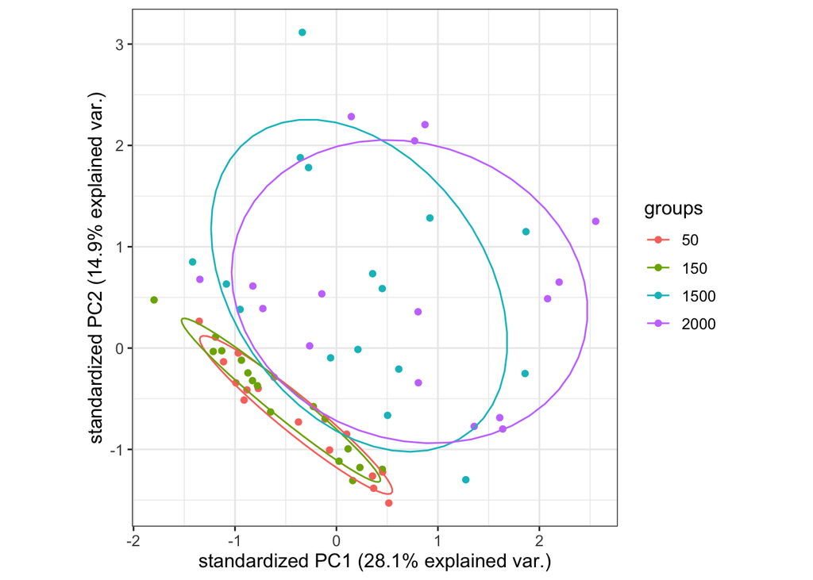

```r
ggbiplot(liver.pca, ellipse = TRUE, groups = as.factor(liver$Dose.Group),
         var.axes = FALSE)+
  theme_bw()+
  theme(text = element_text(size=12))
```

```r
# Yes, it appears that the dosage of acetomenaphin given to a rat
#   differentially affects its gene expression. Higher doses have more
#   similar and more variable gene expression, and lower doses have
#   more similar, and less variable gene expression.
```

**Q4** Let’s look at the loading scores for the first 10 genes and the first 4 PC axes. When considering gene A_43_P2128, which PC axis does it load most strongly on (of the first 4 axes)? What is the direction of this loading?

```r
liver.pca$rotation[1:10,1:4]
```

```
##                        PC1           PC2           PC3           PC4
## A_43_P14555  -0.0076521186 -0.0066316179 -0.0115130681  0.0039459332
## A_43_P22290  -0.0112875766 -0.0004515774 -0.0074977927 -0.0014921496
## A_43_P20792  -0.0041618736  0.0046244166  0.0035619454 -0.0096953243
## A_43_P21286   0.0021992201  0.0051239696  0.0023490481 -0.0067657569
## A_43_P12995  -0.0139183371  0.0009900183  0.0022137750 -0.0106164318
## A_43_P15834  -0.0075736151 -0.0066949445 -0.0001270878 -0.0120724454
## A_43_P12356  -0.0049631020  0.0133750095 -0.0028733709 -0.0199608011
## A_42_P564516 -0.0007001314  0.0085114055  0.0032487300 -0.0008052942
## A_43_P22018  -0.0047838927  0.0084622719  0.0131148432 -0.0066188173
## A_43_P21075  -0.0100758184  0.0020796649 -0.0121424405 -0.0012025034
```

```r
# A_43_P2128 loads most strongly on PC4, and the direction
#   is negative.
```

**Q5** If you wanted to look at the actual PC values for each axis on each rat, you need to pull out the x values from your pca object (the vale of the rotated data - nonstandardized). Do this for the first 10 rows and the first 4 columns. Describe where rat 3 falls on the PC axes.

```r
liver.pca$x[1:10,1:4]
```

```
##              PC1        PC2        PC3        PC4
##  [1,] -32.919987  -2.903989  0.1345132 -1.4255611
##  [2,] -29.325308  -7.377597  1.0317613 -6.0964553
##  [3,]  13.451222 -26.326953 -3.0316212 11.2340014
##  [4,]  10.838734 -29.763389 -9.5342540 23.1543764
##  [5,] -26.084400  -8.884672 -5.1615991 11.2860412
##  [6,] -40.009316   5.695810  1.0296957 10.5181543
##  [7,] -11.076502 -15.697433 -0.8770989  0.3295460
##  [8,]  15.261685 -32.907824 -7.7505123  9.2767055
##  [9,]  -2.016981 -21.644212  2.1073569  0.7710166
## [10,] -22.812666  -8.578348 -0.1336499  5.6560465
```

```r
# Rat 3 has these values on the PC axes
# PC1: 13.451222
# PC2: -26.326953
# PC3: -3.0316212
# PC4: 11.2340014
```

**Q6** Now try plotting the PCA data and group the points by the Treatment Groups. What hypothesis would you draw from the relationships that stand out from this figure?

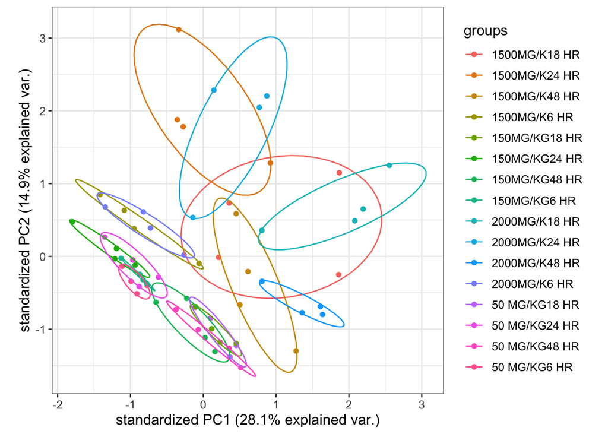

```r
ggbiplot(liver.pca, ellipse = TRUE, groups = as.factor(liver$Treatment.Group),
         var.axes = FALSE)+
  theme_bw()+
  theme(text = element_text(size=12))
```

```r
# Depending on how often you take each dose (every 6,18,24, or 48 hours),
#   you get a different  gene expression, so you need to take time
#   into consideraiton when dosing with acetomenaphin.
```